# Use Neural Network

### 2016/08/05 tjw at jobspace

# Neural Network?

## Supervised Learning

[figure not shown]

> I see you as a human being. I will educate you well.

> --Ma Ying-jeou
- Training material
- Grading/score
- Training method
- Test

## MNIST

[figure not shown]

## Font

[figure not shown]

## Waifu2x

[figure not shown]

CC-BY-NC "For Creators", http://piapro.net/en_for_creators.html

```python
IFrame("https://tjwei.github.io/2048-NN", "90%", 800)
```

[interactive chart not shown]

## Tools

- Theano/lasagne
- Keras
- Tensorflow/tflearn
- neon
- torch
- caffe

# End of the story?

## Issues (Type I)

- Q without A
- Not enough samples
- How to encode the problem?

## Researching direction

e.g. https://openai.com/blog/generative-models/

# There are plenty of low hanging fruits

### (unless you are doing research)

# Issues (Type II)

## My model is not learning

# Feedforward Neural Network

[figure not shown]

```python
l_in = InputLayer(shape=(None, 2))
l_hidden = DenseLayer(l_in, num_units=3)
l_out = DenseLayer(l_hidden, num_units=1, nonlinearity=sigmoid)
```

[figure not shown]

### $$ Wx+b $$

## Activation function

[figure not shown]

# Use it

> "If you have one, try to use it please!"

> --Dr. Gregory House
- Encoding the problem
  - fixed length
  - discrete -> one hot
  - range
- Logic complexity
- Number of features?

## CNN

- Convolution (correlation)
- Kernel
- Pool

> Love thy neighbor

## Using hidden layers

[figure not shown]

## Neural Matching

https://github.com/tjwei/Neural-Matching/blob/master/matching-theano-VGG-one-patch.ipynb

## Generative Adversarial Networks

> What I cannot create, I do not understand.

> --Richard Feynman

# Educate your NN

> Education is the most powerful weapon which you can use to change the world.

> --Nelson Mandela

# Empathy: You were a student too

# Overfitting

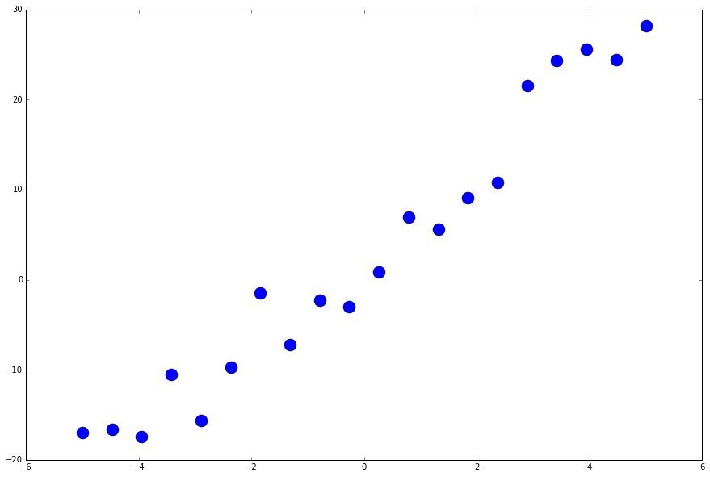

```python
y = 5*x+3+error
plot(x, y, 'o', markersize=15);
```

### Polynomial fit

[figure not shown]

## Test

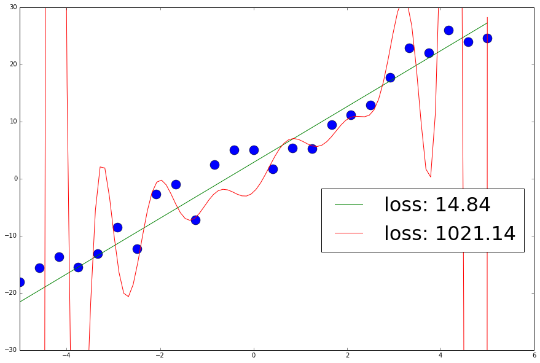

```python
plot(x2,y2, 'o', markersize=15);plot(x0, p1(x0), label=label1);plot(x0, p20(x0), label=label20);plt.axis([-5, 6, -30, 30])
legend(bbox_to_anchor=(1, 0.5), fontsize=32);
```

# Dropout

> The more constraints one imposes, the more one frees one’s self…

> the arbitrariness of the constraint serves only to obtain precision of execution.

> --Igor Stravinsky

# The 10,000 Hour Rule

> “The master has failed more times than the beginner has even tried.”

> --Stephen McCranie

# Learning is all about generalization

> All generalizations are false, including this one.

> --Mark Twain

# Making Mistakes is essential

> I will close my door to shut out all possible errors.

> “But how am I to enter in?” cried Truth.

> --Tagore

# You cannot learn from textbook

> “We learn from failure, not from success!”

> --Bram Stoker, Dracula

# Reinforcement Learning

> Education is learning what you didn't even know you didn't know.

> --Daniel J. Boorstin

# Exploration

# vs.

# Exploitation

[figure not shown]

> “Have no fear of perfection - you'll never reach it.” --Salvador Dalí

[figure not shown]

# Q&A

> “Freedom is not worth having if it does not include the freedom to make mistakes.”

> --Mahatma Gandhi